# Warsztaty badawcze - zadanie 3

Magdalena Mazurek, Piotr Smuda, Bartosz Topolski

March 30, 2017

# 1. Cel Raportu

Za cel poniższego raportu obraliśmy pokazanie podstawowych statystyk dla zadań, dotyczących wyników i czasów ich rozwiązywania w podziale na kraje. Aby zawęzić naszą analizę postanowiliśmy skupić się na pięciu wybranych krajach:

1. Polska,
2. Korea Południowa,
3. Stany Zjednoczone,
4. Niemcy,
5. Wielka Brytania.

# 2. Otrzymane wyniki

Wśród otrzymanych wyników rzeczami, na które zwróciliśmy uwagę są:

1. Uczniowie z Korei Południowej rozwiązują zadania szybko i poprawnie, ale za to są bardzo aktywni patrząc na liczbę wykonanych przez nich akcji. Może to wynikać z faktu, że sport elektroniczny (zawodowe granie na komputerze) jest ich sportem narodowym, przez co od najmłodszych lat uczą się tego w szkole i po zajęciach. Natomiast jeśli spojrzymy na uczniów z Niemiec, to można zauważyć, że skuteczność rozwiązywania zadań mają porównywalną do swoich rówieśników z Korei, ale potrzebują na to średnio więcej czasu i mniej akcji.
2. Jeśli spojrzy się na różne typy zadań, to widać, że uczniowie, niezależnie od kraju pochodzenia, najwięcej czasu poświęcają na matematykę, co nie przekłada się na ich wyniki. Mianowicie, w każdym kraju najmniej rozwiązanych poprawnie zadań w porównaniu do czytania i nauk ścisłych jest z matematyki.
3. Z wybranych przez nas krajów najlepiej z zadaniami różnych typów radzą sobie uczniowie z Korei Południowej, a najgorzej ze Stanów Zjednoczonych, co potwierdza oficjalny ranking PISA 2012.

# 3. Analiza i wizualizacja

## 3.1 Wykres czasu rozwiązywania zadań

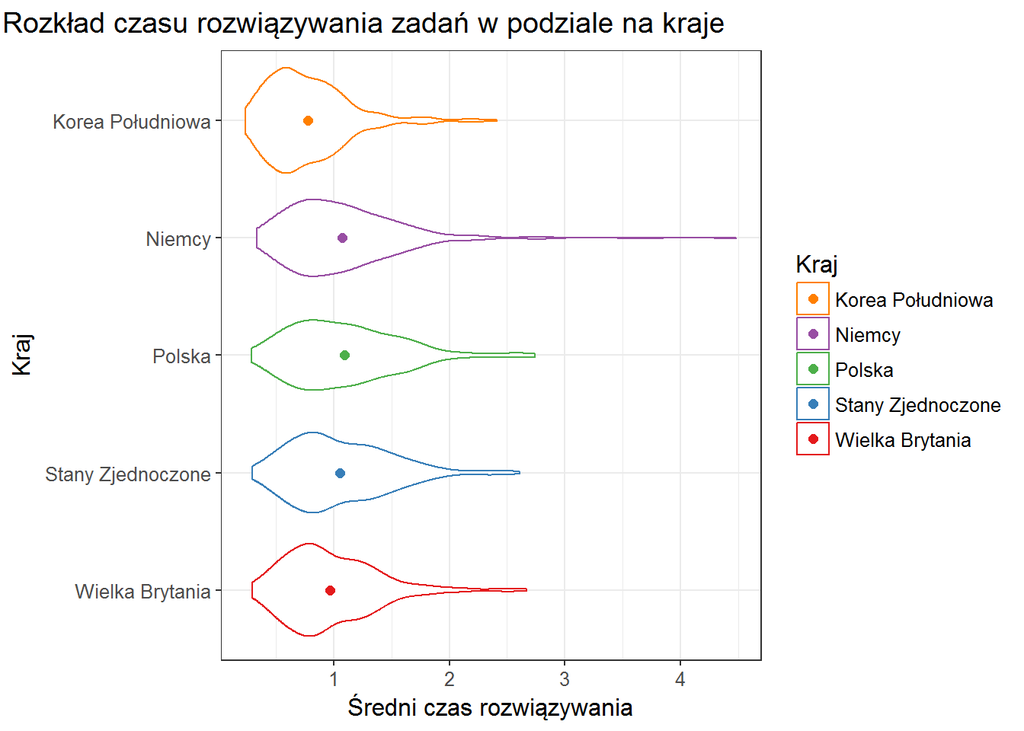

Na powyższym wykresie został przedstawiony rozkład czasu rozwiązywania zadań w podziale na kraje. Widać na nim, że uczniowie z Korei Południowej znacząco odstają prędkością rozwiązywania od uczniów pozostałych krajów, dla których otrzymane wyniki są podobne.

## 3.2 Wykres rozkładu liczby akcji w podziale na kraje

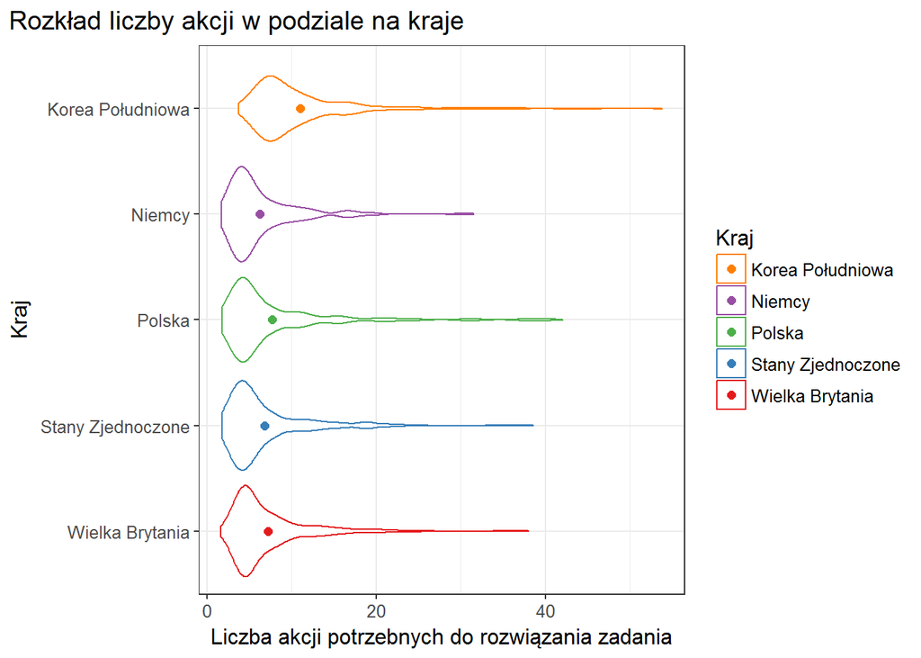

Na powyższym wykresie został przedstawiony rozkład liczby akcji potrzebnych do rozwiązania zadań w podziale na kraje. Widać na nim, że ponownie uczniowie z Korei Południowej znacząco odstają od swoich rówieśników z pozostałych krajów, dla których otrzymane wyniki znów są podobne, i potrzebują wykonać od nich więcej akcji.

## 3.3 Wykres odsetku w pełni rozwiązanych zadań w podziale na kraje

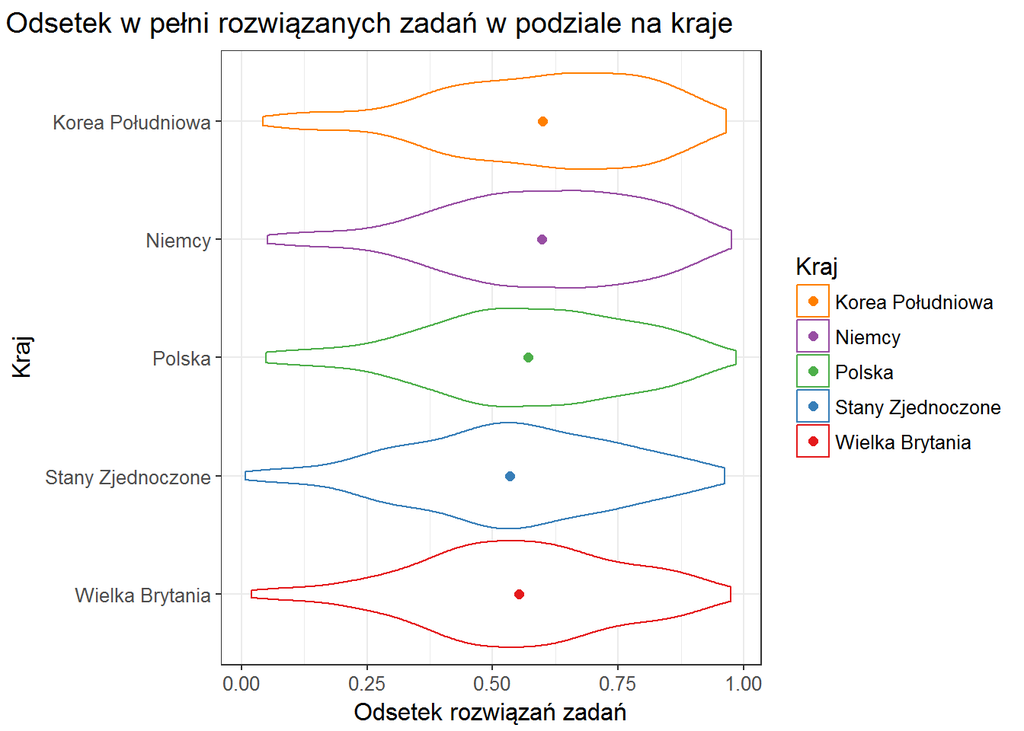

## 3.4 Wykres zależności odsetku w pełni rozwiązanych zadań od czasu

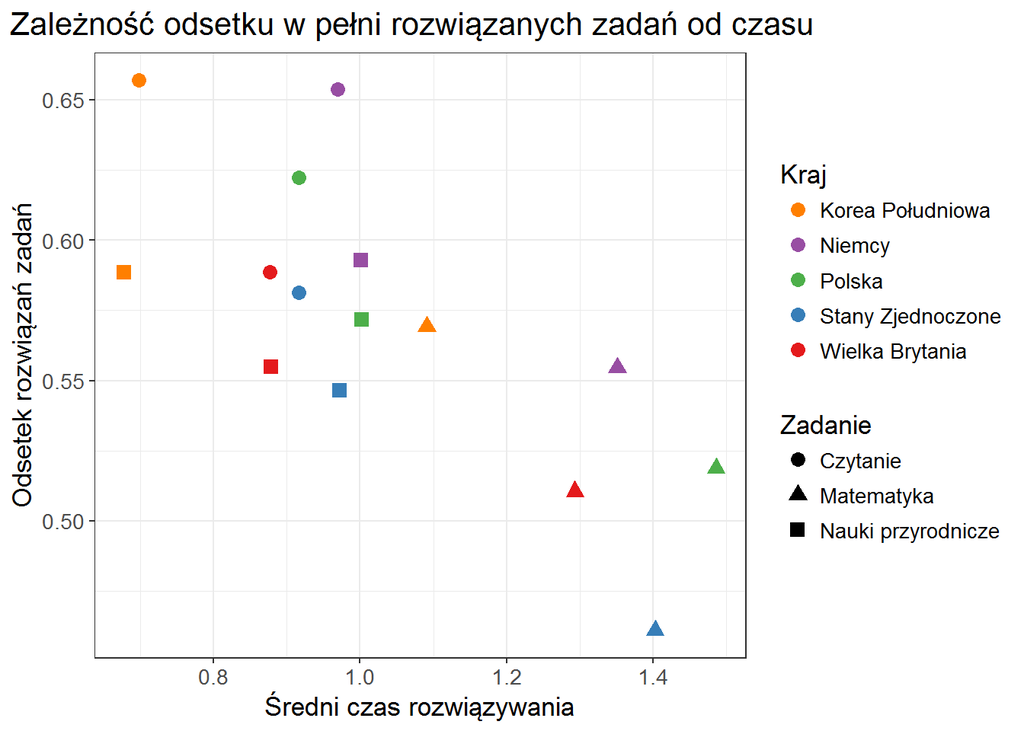

Na powyższym wykresie został przedstawiony stosunek odsetku w pełni rozwiązanych zadań od czasu w podziale na kraje oraz typy zadań. Widać na nim, że uczniowie z Korei Południowej ogólnie wypadają najlepiej na tle swoich rówieśników z innych krajów, niezależnie od typu zadania. Ponadto widać, że uczniowie wszystkich krajów najgorzej radzą sobie z zadaniami z matematyki.

## 3.5 Czas rozwiązywania zadań

| item_short | CNT | min | q1 | weighted_median | weighted_mean | q3 | max |
| --- | --- | --- | --- | --- | --- | --- | --- |
| M00GQ01 | DEU | 0.1852000 | 1.406367 | 1.93 | 2.18 | 2.638792 | 17.482717 |
| M00GQ01 | GBR | 0.1709000 | 1.258962 | 1.75 | 2.07 | 2.509883 | 10.534300 |
| M00GQ01 | KOR | 0.0694000 | 1.039329 | 1.50 | 1.69 | 2.148538 | 8.138767 |
| M00GQ01 | POL | 0.1706500 | 1.577067 | 2.21 | 2.56 | 3.267983 | 14.724767 |
| M00GQ01 | USA | 0.1999667 | 1.333946 | 1.91 | 2.25 | 2.849063 | 12.701417 |

Powyższa tabela przedstawia przykładowe wiersze ze statystykami czasu rozwiązywania zadań. Na przykładzie przedstawione zostały wyniki dla zadania `M00GQ01`.

## 3.6 Rodzaje zakończenia rozwiązywania zadań

| item_short | CNT | full_credit | no_credit |
| --- | --- | --- | --- |
| M00GQ01 | DEU | 48 | 630 |
| M00GQ01 | GBR | 95 | 1433 |
| M00GQ01 | KOR | 73 | 553 |
| M00GQ01 | POL | 71 | 632 |
| M00GQ01 | USA | 34 | 604 |

Powyższa tabela przedstawia przykładowe wiersze ze statystykami rozwiązania / nie rozwiązania zadań. Na przykładzie przedstawione zostały wyniki dla zadania `M00GQ01`.

## 3.7 Liczba akcji potrzebnych do rozwiązania zadań

| item_short | CNT | min | q1 | weighted_median | weighted_mean | q3 | max |
| --- | --- | --- | --- | --- | --- | --- | --- |
| M00GQ01 | DEU | 3 | 3 | 4 | 9.82 | 8 | 260 |
| M00GQ01 | GBR | 2 | 3 | 5 | 13.40 | 12 | 1302 |
| M00GQ01 | KOR | 3 | 5 | 11 | 21.78 | 27 | 1055 |
| M00GQ01 | POL | 3 | 4 | 15 | 24.12 | 35 | 172 |
| M00GQ01 | USA | 3 | 4 | 5 | 13.99 | 16 | 579 |

Powyższa tabela przedstawia przykładowe wiersze ze statystykami liczby akcji potrzebnych do rozwiązania zadań. Na przykładzie przedstawione zostały wyniki dla zadania `M00GQ01`.

# 4. Wykorzystany kod

```r
#############################
# Wczytanie pakietów i danych
library(dplyr)
library(isotone)
library(knitr)
library(stringi)
library(ggplot2)

load("../data/processed_data/dane_pisa_merged_final_26032017.RDA")

# Zamiana timingu na minuty
dane_pisa_merged_final$timing <- dane_pisa_merged_final$timing / 60000

# Wybór krajów
chosen_countries <- c("POL", "KOR", "USA", "DEU", "GBR")
n <- length(chosen_countries)

# Pozbycie się braków danych
dane_pisa_merged_final <- dane_pisa_merged_final %>%
  filter(!is.na(timing) & !is.na(n.actions) & !is.na(result))

##########################
# Czas rozwiązywania zadań

result_timing <- dane_pisa_merged_final %>% group_by(item_short, CNT) %>%
   summarise(min = min(timing, na.rm = TRUE),
          q1 = quantile(timing, 0.25, na.rm = TRUE),
          weighted_median = round(weighted.median(timing, W_FSTUWT), 2),
          weighted_mean = round(weighted.mean(timing, W_FSTUWT, na.rm = TRUE), 2),
          q3 = quantile(timing, 0.75, na.rm = TRUE),
          max = max(timing, na.rm = TRUE))

write.csv(result_timing, file = "../data/processed_data/result_timing.csv", row.names = FALSE)

result_timing_subset <- result_timing %>% filter(CNT %in% chosen_countries)

kable(head(result_timing_subset, 5))

#########################################
# Rodzaje zakończenia rozwiązywania zadań

result_result <- dane_pisa_merged_final %>% group_by(item_short, CNT) %>%
   summarise(full_credit = sum(ifelse(is.na(result), 0, result == 1)),
             no_credit = sum(ifelse(is.na(result), 0, result == 0)),
             other = sum(is.na(result)))

write.csv(result_result, file = "../data/processed_data/result_result.csv", row.names = FALSE)

result_result_subset <- result_result %>% filter(CNT %in% chosen_countries)

kable(head(result_result_subset, 5))

###############################################
# Liczba akcji potrzebnych do rozwiązania zadań

result_n_actions <- dane_pisa_merged_final %>% group_by(item_short, CNT) %>%
   summarise(min = min(n.actions, na.rm = TRUE),
             q1 = quantile(n.actions, 0.25, na.rm = TRUE),
             weighted_median = round(weighted.median(n.actions, W_FSTUWT), 2),
             weighted_mean = round(weighted.mean(n.actions, W_FSTUWT, na.rm = TRUE), 2),
             q3 = quantile(n.actions, 0.75, na.rm = TRUE),
             max = max(n.actions, na.rm = TRUE))

write.csv(result_n_actions, file = "../data/processed_data/result_n_actions.csv", row.names = FALSE)

result_n_actions_subset <- result_n_actions %>% filter(CNT %in% chosen_countries)

kable(head(result_n_actions_subset, 5))

########################
# Wizualizacja i analiza

# Obróbka danych
merged_data <- left_join(result_timing_subset, result_n_actions_subset, by = c("item_short", "CNT"))
merged_data <- left_join(merged_data, result_result_subset, by = c("item_short", "CNT"))
merged_data <- merged_data %>%
  mutate(credit_percentage = full_credit/(full_credit + no_credit),
         Zadanie = stri_sub(item_short, 1, 1)) %>%
  group_by(CNT, Zadanie) %>%
  mutate(mean_timing = mean(weighted_mean.x),
         mean_result = mean(credit_percentage)) %>%
  select(CNT, weighted_mean.x, weighted_mean.y, credit_percentage,
         Zadanie, mean_timing, mean_result)

merged_data$CNT[which(merged_data$CNT == "GBR")] <- "Wielka Brytania"
merged_data$CNT[which(merged_data$CNT == "DEU")] <- "Niemcy"
merged_data$CNT[which(merged_data$CNT == "KOR")] <- "Korea Południowa"
merged_data$CNT[which(merged_data$CNT == "POL")] <- "Polska"
merged_data$CNT[which(merged_data$CNT == "USA")] <- "Stany Zjednoczone"

merged_data$Zadanie[which(merged_data$Zadanie == "M")] <- "Matematyka"
merged_data$Zadanie[which(merged_data$Zadanie == "R")] <- "Czytanie"
merged_data$Zadanie[which(merged_data$Zadanie == "S")] <- "Nauki przyrodnicze"
names(merged_data)[which(names(merged_data) == "CNT")] <- "Kraj"
merged_data <- merged_data %>% group_by(Kraj) %>% arrange(desc(Kraj))

merged_data$Kraj <- factor(merged_data$Kraj, levels = unique(merged_data$Kraj))

# Violin plot dla czasu rozwiązywania zadań
vp1 <- ggplot(merged_data, aes(x = Kraj, y = weighted_mean.x, color = Kraj)) +
  geom_violin() +
  ggtitle("Rozkład czasu rozwiązywania zadań w podziale na kraje") +
  ylab("Średni czas rozwiązywania") +
  theme_bw() +
  scale_colour_brewer(palette = "Set1", breaks = rev(merged_data$Kraj)) +
  theme(text=element_text(size = 12)) +
  theme(plot.title = element_text(hjust = 1.2)) +
  stat_summary(fun.y = mean, geom = "point", size = 2) +
  coord_flip()
vp1

# Violin plot dla liczby akcji
vp2 <- ggplot(merged_data, aes(x = Kraj, y = weighted_mean.y, color = Kraj)) +
  geom_violin() +
  ggtitle("Rozkład liczby akcji w podziale na kraje") +
  ylab("Liczba akcji potrzebnych do rozwiązania zadania") +
  theme_bw() +
  scale_colour_brewer(palette = "Set1", breaks = rev(merged_data$Kraj)) +
  theme(text=element_text(size = 12)) +
  theme(plot.title = element_text(hjust = -6.2)) +
  stat_summary(fun.y = mean, geom = "point", size = 2) +
  coord_flip()
vp2

# Violin plot dla odsetek w pełni rozwiązanych zadań
vp3 <- ggplot(merged_data, aes(x = Kraj, y = credit_percentage, color = Kraj)) +
  geom_violin() +
  ggtitle("Odsetek w pełni rozwiązanych zadań w podziale na kraje") +
  ylab("Odsetek rozwiązań zadań") +
  theme_bw() +
  scale_colour_brewer(palette = "Set1", breaks = rev(merged_data$Kraj)) +
  theme(text=element_text(size = 12)) +
  theme(plot.title = element_text(hjust = 1.15)) +
  stat_summary(fun.y = mean, geom = "point", size = 2) +
  coord_flip()
vp3

# Wykres zależności odsetku w pełni rozwiązanych zadań od czasu
sp <- ggplot(merged_data, aes(x = mean_timing, y = mean_result, color = Kraj, shape = Zadanie)) +
  geom_point(size = 3) +
  ggtitle("Zależność odsetku w pełni rozwiązanych zadań od czasu") +
  xlab("Średni czas rozwiązywania") +
  ylab("Odsetek rozwiązań zadań") +
  theme_bw() +
  scale_colour_brewer(palette = "Set1", breaks = rev(merged_data$Kraj)) +
  theme(text=element_text(size = 13)) +
  theme(plot.title = element_text(hjust = 0.55))
sp
```

# 5. Informacja o sesji

```
 setting  value
 version  R version 3.3.2 (2016-10-31)
 system   x86_64, mingw32
 ui       RTerm
 language (EN)
 collate  Polish_Poland.1250
 tz       Europe/Warsaw
 date     2017-04-05
```

```
Packages ------------------------------------------------------------------
```

```
 package      * version date       source
 assertthat     0.1     2013-12-06 CRAN (R 3.3.1)
 backports      1.0.5   2017-01-18 CRAN (R 3.3.2)
 codetools      0.2-15  2016-10-05 CRAN (R 3.3.2)
 colorspace     1.3-2   2016-12-14 CRAN (R 3.3.2)
 DBI            0.6-1   2017-04-01 CRAN (R 3.3.3)
 devtools       1.12.0  2016-06-24 CRAN (R 3.3.3)
 digest         0.6.12  2017-01-27 CRAN (R 3.3.3)
 dplyr        * 0.5.0   2016-06-24 CRAN (R 3.3.2)
 evaluate       0.10    2016-10-11 CRAN (R 3.3.2)
 ggplot2      * 2.2.1   2016-12-30 CRAN (R 3.3.2)
 gtable         0.2.0   2016-02-26 CRAN (R 3.3.1)
 highr          0.6     2016-05-09 CRAN (R 3.3.1)
 htmltools      0.3.5   2016-03-21 CRAN (R 3.3.1)
 isotone      * 1.1-0   2015-07-24 CRAN (R 3.3.2)
 knitr        * 1.15.1  2016-11-22 CRAN (R 3.3.2)
 labeling       0.3     2014-08-23 CRAN (R 3.3.0)
 lazyeval       0.2.0   2016-06-12 CRAN (R 3.3.1)
 magrittr       1.5     2014-11-22 CRAN (R 3.3.1)
 memoise        1.0.0   2016-01-29 CRAN (R 3.3.2)
 munsell        0.4.3   2016-02-13 CRAN (R 3.3.1)
 nnls           1.4     2012-03-19 CRAN (R 3.3.2)
 plyr           1.8.4   2016-06-08 CRAN (R 3.3.1)
 R6             2.2.0   2016-10-05 CRAN (R 3.3.2)
 RColorBrewer   1.1-2   2014-12-07 CRAN (R 3.3.0)
 Rcpp           0.12.10 2017-03-19 CRAN (R 3.3.3)
 rmarkdown      1.4     2017-03-24 CRAN (R 3.3.3)
 rprojroot      1.2     2017-01-16 CRAN (R 3.3.2)
 scales         0.4.1   2016-11-09 CRAN (R 3.3.2)
 stringi      * 1.1.3   2017-03-21 CRAN (R 3.3.3)
 stringr        1.2.0   2017-02-18 CRAN (R 3.3.3)
 tibble         1.3.0   2017-04-01 CRAN (R 3.3.3)
 withr          1.0.2   2016-06-20 CRAN (R 3.3.3)
 yaml           2.1.14  2016-11-12 CRAN (R 3.3.2)
```